# Using R to Predict Antimicrobial Resistance Rates.

Analysis performed using antimicrobial susceptibility test data for all isolates from blood cultures collected at NUTH from Q1 2019 onwards.

Daniel Weiand

Newcastle upon Tyne Hospitals NHS Foundation Trust

Friday, 30 June, 2023

## Session aims

1. Introduce R
2. Point out useful learning resources
3. Run through a working example of a project completed (in its entirety) using R

[figure not shown]

## What is R?

- R is one of the most commonly used languages for data science, together with Python.
- R is a powerful, free open source data science and statistics environment, used in industry, academia and major corporations (eg Microsoft, Google, Facebook).
- R benefits from a worldwide community that freely shares learning and resources, through e.g. [GitHub](https://github.com/send2dan/)

[figure not shown]

## Let’s start with the elephant in the room

[figure not shown]

Yes, to use R, we need to learn some code

No, it’s not rocket science.

## Learn to code copy-paste

[figure not shown]

## Why use R for data science?

- Data has transformed our world in powerful ways and can help us make better decisions.
- Almost every interaction with the health service leaves a digital trace - raw information that has phenomenal potential.
- But raw data is not powerful on its own. It must be shaped, checked, curated and analysed. And then it must be communicated, and acted upon. This work requires people, with modern data skills, in teams, using platforms like R to do the heavy lifting and avoid needless duplication of effort.
- The [Goldacre report](https://assets.publishing.service.gov.uk/government/uploads/system/uploads/attachment_data/file/1067053/goldacre-review-using-health-data-for-research-and-analysis.pdf) actively promotes the use of R in the NHS.
- NUTH now actively supports the use of R at scale, and it can be installed on any work PC (simply call IT and ask to be added the “SCCM-R” group)

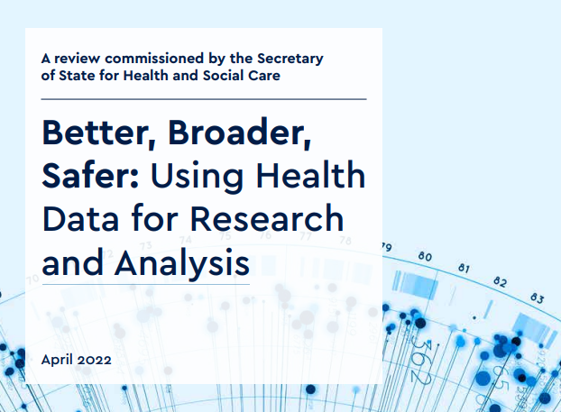

## Many of you are already familiar with R

[figure not shown]

## NHS-R

- The Health Foundation supports [NHS-R](https://nhsrcommunity.com/about/), which delivers **free**-to-NHS-staff online training.
- It’s **free** to register.
- Courses are really popular and spaces are limited to about 20 per session. Sessions are scheduled once a month. To be notified when further dates are scheduled, please contact: nhs.rcommunity@nhs.net
- [NHS-R](https://nhsrcommunity.com/about/) runs the premier data science conference in the NHS, along with regular skill-based webinars.
- [NHS-R](https://nhsrcommunity.com/about/) supports a thriving [Slack](https://nhsrcommunity.slack.com/) community

[figure not shown]

[figure not shown]

## Other useful resources

- [NHS-R](https://nhsrcommunity.com/about/) is active on [#twitter](https://www.twitter.com/)
- The #Rstats and #TidyTuesday hashtags are excellent
- There are lots of good [online courses](https://www.edx.org/course/data-science-r-basic)
- And lots of excellent [freely available textbooks](https://r4ds.had.co.nz/).

[figure not shown]

[figure not shown]

## R helps maintain momentum and promotes collaboratoration

We know that projects can quickly lose momentum and get stuck

[figure not shown]

## R can beat mission creep

“Just one more subanalysis”

[figure not shown]

Think: Re-running reports after filtering the data by various substrata.

## R easily handles big (and growing) data sets

“Just a bit more data”

[figure not shown]

Think: Re-running reports when more data becomes available.

## R can help you get to the end

“Just (one more… last… final!) final report”

[figure not shown]

Think: Re-drafting the same report multiple times to get your paper accepted through peer review

## R supports reproducible research and QI

[interactive chart not shown]

## This presentation was written in R

[figure not shown]

## And these papers were written entirely in R

[figure not shown]

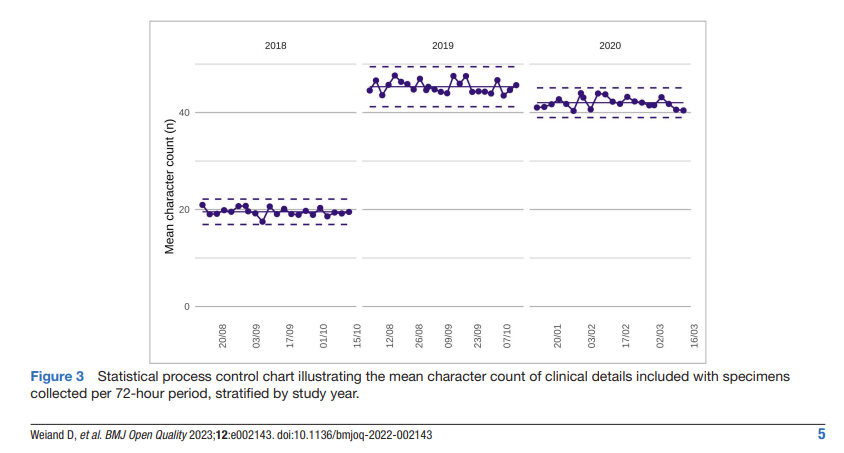

[figure not shown]

[figure not shown]

## R and python are quickly overtaking SAS, SPSS and Stata

- In terms of jobs

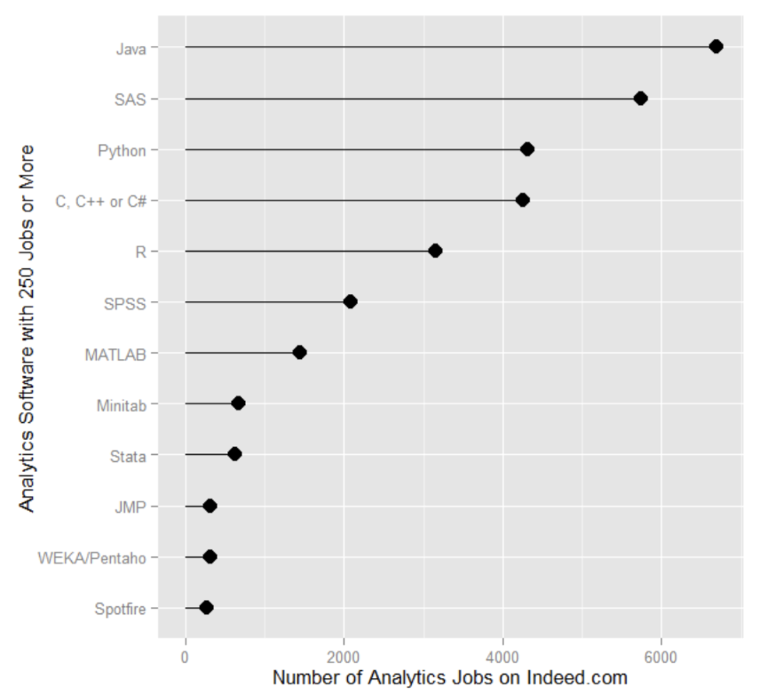

- In terms of output

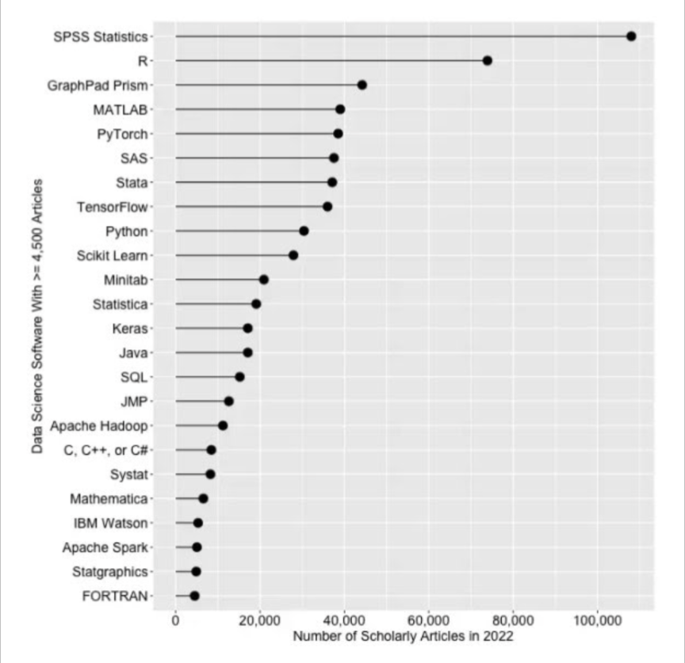

- In terms of impact

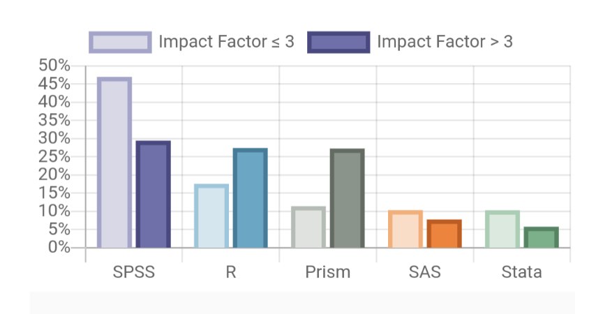

## R and python are quickly overtaking SAS, SPSS and Stata

- In terms of Google scholar hits

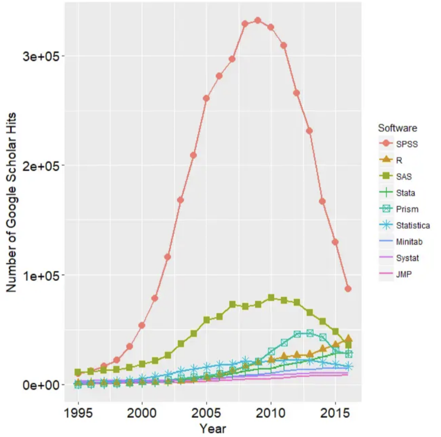

- In terms of Stack Overflow queries

[figure not shown]

## Avoiding excel has its benefits

[figure not shown]

## So now for a working example

- Aim: Predict Antimicrobial Resistance (AMR) Rates for Blood Culture Isolates at NUTH, using R
- Objectives:
  - Import blood culture data into R
  - Wrangle, visualise, and exploring data using R
  - Analyse historical AMR rates, and model future AMR rates using R

## Methods

[figure not shown]

- The LIMS was interrogated to collect data on all culture-positive blood cultures collected between 2019-04-01 and 2023-03-31

## The AMR package

[figure not shown]

- The [AMR](https://msberends.github.io/AMR/articles/AMR.html) package [1,2] is a free, open-source and independent package for [R](https://nhsrcommunity.com/installing-r-and-r-studio/) [3] that provides a standard for clean and reproducible analysis and prediction of Antimicrobial Resistance (AMR).
- This package was used to determine ‘first isolates’, as per Hindler et al [4], for use in the final analysis; calculate and visualise AMR data; and predict future AMR rates using regression models.

## Predicting future AMR rates

[figure not shown]

- The [AMR](https://msberends.github.io/AMR/articles/AMR.html) package [1,2] includes functions which, based on a date column, calculates cases per year and uses a regression model to predict antimicrobial resistance.
- The resistance_predict() function creates a prediction model including standard errors (SE), which are returned as columns se_min and se_max.
- Valid options for the statistical model (argument model) are: “binomial”, “poisson” and “linear”.

## Totals

- In total, 11098 distinct positive blood cultures were collected from 6888 distinct patients, leading to isolation of 12272 organisms.
- Taking into consideration **‘first isolates’** only, 8780 distinct positive blood cultures were collected from 6888 distinct patients, leading to isolation of 9648 organisms.
- **From this point onwards, this analysis concentrates only on ‘first isolates’ from blood cultures, to intelligently de-duplicate the data**

## Location of blood culture collection

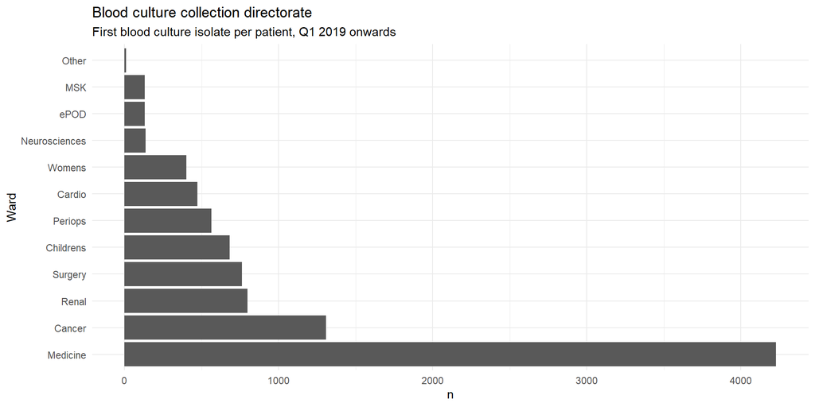

## Location of blood culture collection

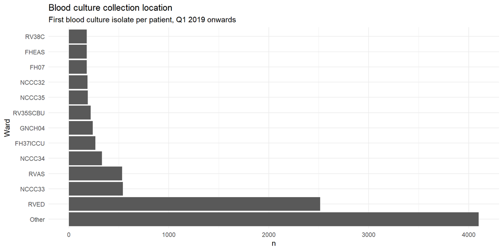

## Age-related data

Age of patients with positive blood cultures

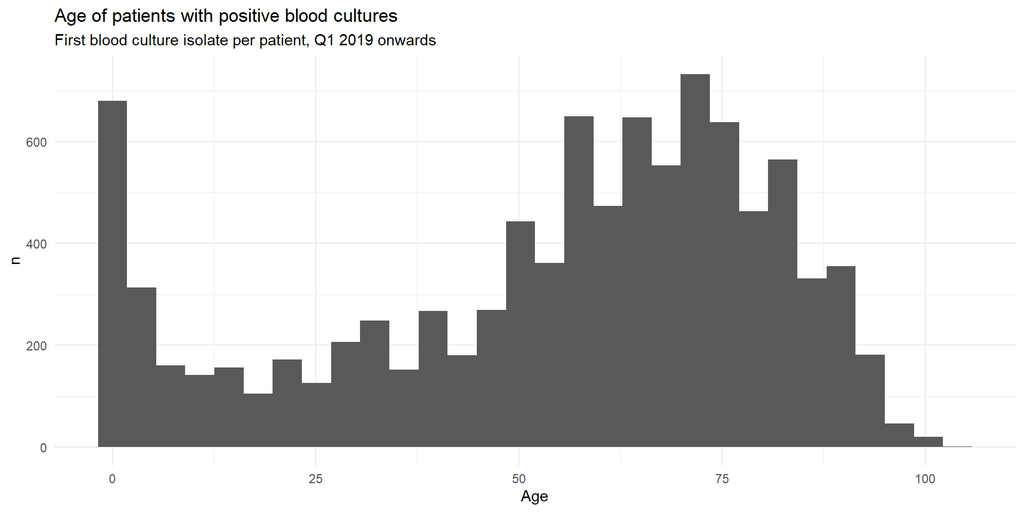